# AmpSeq Colombia Report

Laboratory of Genomic Epidemiology of Malaria

2023-03-12

This is a preliminary report of results of amplicon sequencing (microhaplotypes) of the *P. falciparum* samples collected from August 2020 to August 2022 in four municipalities located in the pacific coast of Colombia and Puerto Inirida located in the border with Venezuela. The report includes the following topics:

1. Performance of the genotyping process.
2. Molecular surveillance of drug resistance.
3. Monitoring transmission intensity.
4. Measuring geographic connectivity.

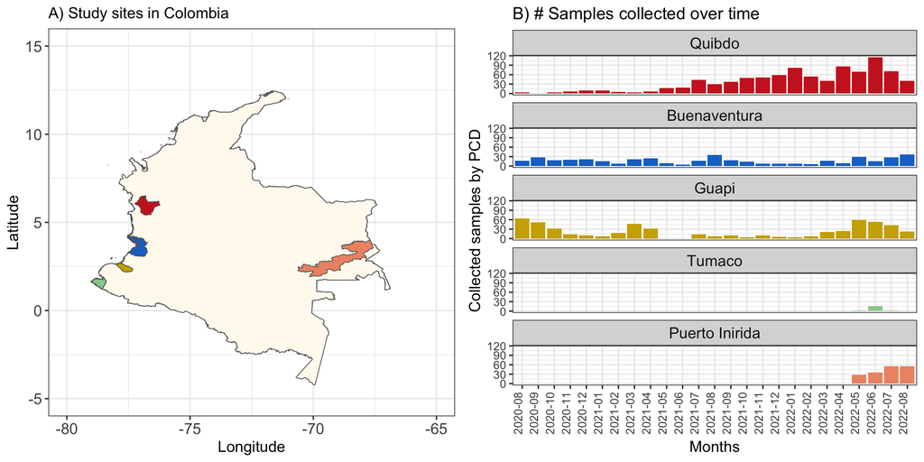

# 1 Performance of the genotyping process

The performance of the genotyping process was assesed in terms of the proportion of samples amplified by each locus (amplification rate by locus) and the proportion of loci amplified per each sample (amplification rate per sample). Only alleles with read depths above 10 were considered as true alleles, and loci were considered as heterozygous if the read depth of the minor allele was at least 10% the read depth of the mayor allele.

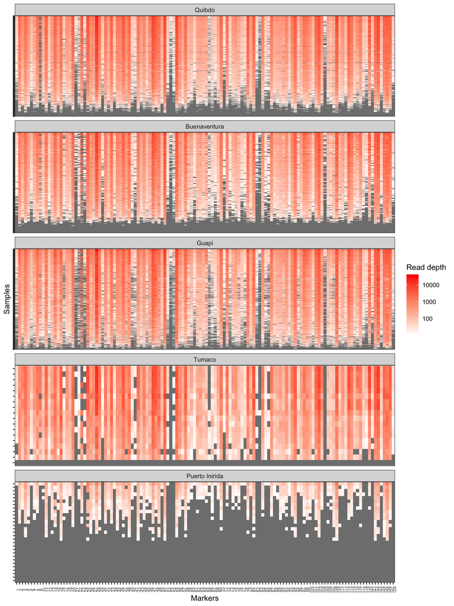

**Figure 2:** Read depth by loci (x-axis) and samples (y-axis).

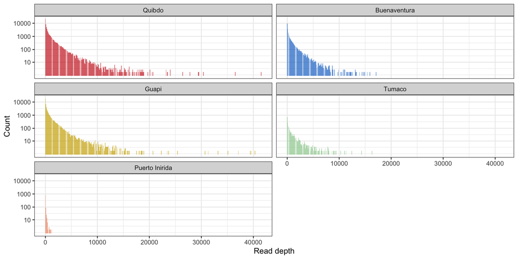

**Figure 3:** Histogram of the read depth by study area.

## 1.1 Amplification rate by locus

The minimum proportion of samples that a marker should amplify in order to be keep it for further analysis was set to 0.65, and all markers below this `threshold` were discarded.

Thus in this data set 113 loci had an amplification rate above 0.65, and 15 loci were discarded. All discarded loci are stored in the slot `discarded_loci` within the `ampseq_object`. The discarded loci were: PF3D7_0212800, PF3D7_0217200, PF3D7_0311900, ASP, PfMDR1_2, PfMDR1_4, PF3D7_0830800_2, PF3D7_0905600, MSP11.H103.MSP3.7, PF3D7_1125700, PF3D7_1148700_1, PF3D7_1320700, PF3D7_1322200, PF3D7_1333200, PF3D7_1466200.

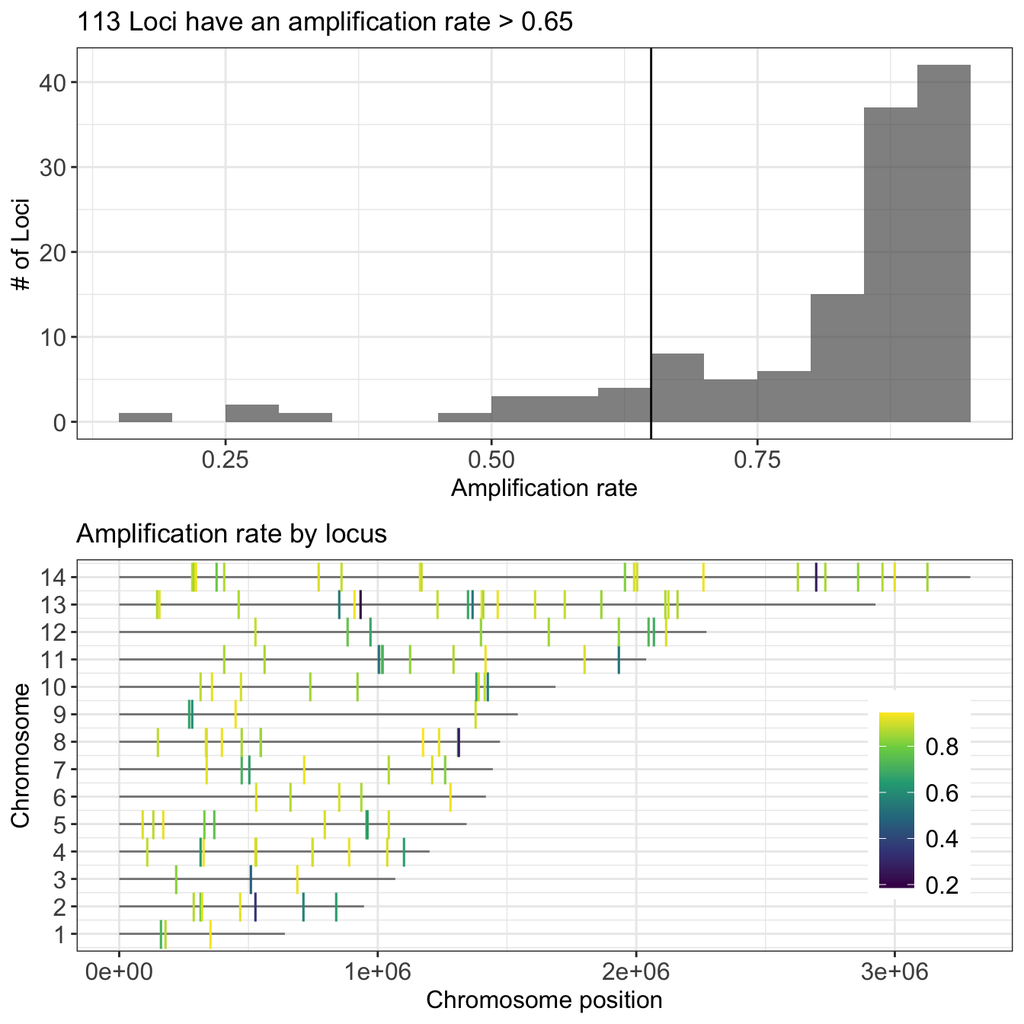

**Figure 4:** Proportion of amplified samples per locus. Top figure shows the distribution of the amplification rate (or proportion of amplified samples) of loci, with the number of loci in the y-axis and the amplification rate in the x-axis. Bottom figure shows the the chromosome location of each locus (chromosomes in y-axis and position in the x-axis) and the gradient color represents its amplification rate.

## 1.2 Amplification rate by sample

Next we measured the proportion of loci amplified per each sample, also called the amplification rate of the samples, and the minmum proportion of loci that a sample should amplified was set to 0.8. All samples bellow this threshold were discarded.

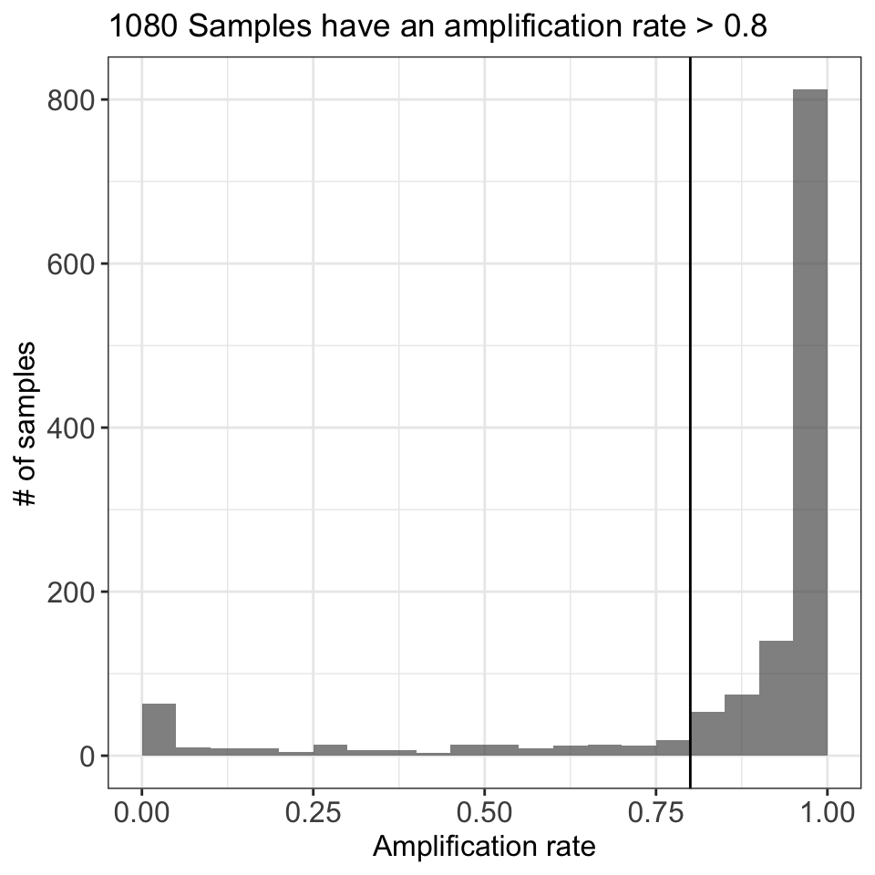

**Figure 5:** Proportion of amplified loci per sample. The figure shows the distribution of the amplification rate (or proportion of amplified loci) of the samples, with the number of samples in the y-axis and the amplification rate in the x-axis.

# 2 Molecular surveillance of drug resistance

Surveillance of polymorphisms or allelic variants associated with resistance against antimalarials is of the utmost importance in public health. That is why our panel of markers includes 5 genes (9 markers in total, some genes are genotyped by more than one marker) that have polymorphisms associated with antimalarial resistance. In this section we identified the different haplotypes of these genes present in our data set, and we determined the frequency of each haplotype in each study area and in each quarter of the year. Each number in the haplotype indicates a position in the amino acid chain, the letter before the number indicates the reference allele (with sensitive phenotype), and the letter after the number is the allele observed in the sample. If the letters are in capital letters, that allele in that position has been previously reported as resistant, whereas the letters in lower case indicate that it is the first time that the position has been reported as polymorphic. In case the sample is polyclonal, each allele observed is separated by the a vertical line `|`, and the order in which they are reported is based on their read count. Null data, that is, sections of the gene that have not been amplified, are completed with the question mark `?`.

For the PfMDR1 gene, the predominant haplotypes were 86N184F1034s1042d1246D and 86N184F1034s1042d1246Y containing the Y184F and D1246Y mutations associated with resistance to lumefantrine and mefloquine. In the PfMDR2 gene (PF3D7_1447900) the most prevalent haplotype was the sensitive haplotype 479y484T492i, except for Puerto Inirida where the predominant haplotype contains a nonsynonymous mutation i492v that has not been reported before. For the PfKelch13 gene, all the samples had the artemisinin-sensitive haplotype, and one sample had a synonymous mutation at the amino acid position 543 (c.1629T>C). In the PfDHFR gene, the most prevalent haplotype was 16a51I59C108N164I, which contains two mutations associated with resistance to pyremethamine (N51I and S108N). In Puerto Inirida samples also carried an additional mutation c50r. In Quibdo and Puerto Iniridad, these haplotypes were fixed; while in Buenaventura, Guapi, and Tumaco the presence of the sensitive haplotype for this drug was also observed. In contrast, the PfDHPS gene haplotype, 436S437G540K581A613A resistant to sulfodoxine, was the most prevalent only in Quibdo, while in the other three study areas the most prevalent haplotype was the sensitive haplotype, except for Puerto Inirida where other three resistant haplotypes were oberved.

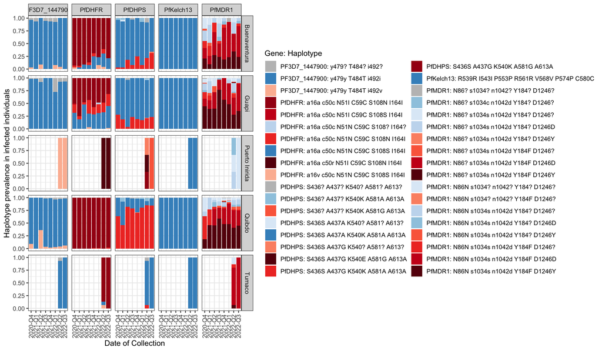

# 3 Monitoring transmission intensity

The transmission of Malaria has an effect on the evolutionary processes that affect the parasite population. Thus, various genetic indicators are used to identify changes in the intensity of transmission at a spatial and temporal level. One of these indicators is the prevalence of polyclonal infections, or the coexistence of two or more different clones (haplotypes) within the infected individual. As the parasite genome is haploid in the human host, the presence of a single haplotype is expected. The presence of two or more different haplotypes in the sample may be due to the transmission of two or more different genotypes from the same bite (co-infection), or the acquisition of parasites by multiple infections or independent bites (super-infection); and both processes are related to the intensity of transmission. In low transmission there are few infective bites, so there is little chance that a person can acquire a super-infection or co-infection, and therefore most infections are monoclonal. On the other hand, when the necessary conditions exist for the increase in the mosquito population and the interaction between them and the human population is favored, super-infections and co-infections increase, generating an increase in the prevalence of polyclonal infections.

The genetic relatedness between parasites is also affected by the intensity of transmission. As we mentioned previously, in low transmission scenarios monoclonal infections are favored, so when an infected person is bitten, a single haplotype is transmitted and self-fertilization of the parasite occurs in the mosquito (sexual reproduction of two genetically identical or related haplotypes). This mechanism of propagation by inbreeding is called clonal propagation, and it causes all the alleles of a haplotype to segregate together and not independently, thus increasing the genetic relatedness in the population. In contrast, when the transmission intensity increase, the genetic relatedness tent to decrease as a consequence of the decrease in inbreeding and the introduction of new clones by mutation, recombination and migration.

## 3.1 Complexity of infection and transmission

In this section we will focus on describing the relationship between the intensity of transmission, inferred through the number of samples collected, and the proportion of polyclonal infections. To do this, we identified polyclonal infections, determined their infection complexity (number of clones coexisting in the sample), and the number of heterozygous loci per sample. We then proceeded to describe the distribution of heterozygous loci per sample, the COI, and the proportion of polyclonal infections in each population. Finally, we described the temporal change in the proportion of polyclonal infections and its association with the number of samples collected.

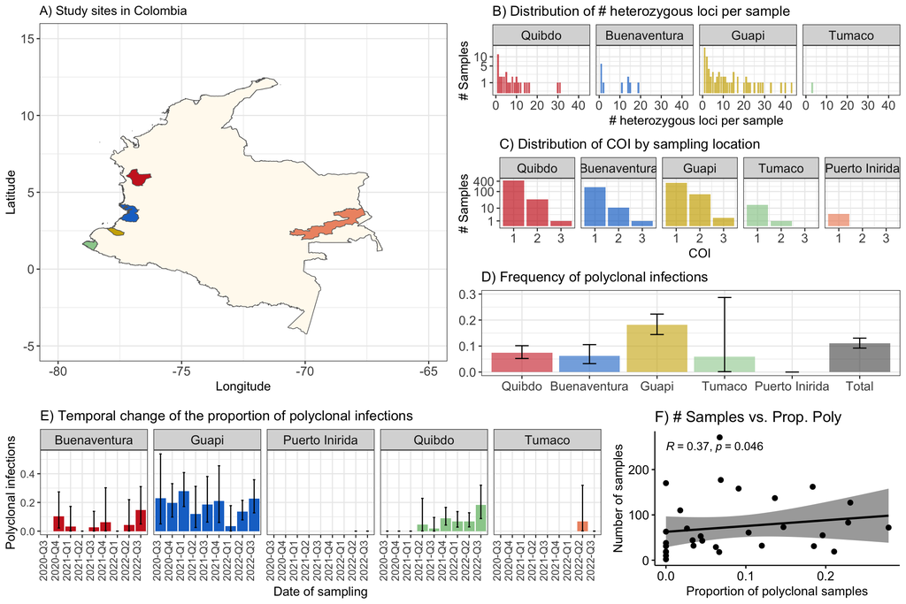

## 3.2 Relatedness and Transmission

Relatedness is defined as the probability that, at any locus in the genome, the alleles sampled from two different individuals are identical by descent (IBD). A Hidden Markov Model based method was developed for the estimation of relatedness (HMMIBD), where the relatedness or $r$ is estimated as a function of the haplotype of the two sampled parasites ($Y_i$ and $Y_j$), the frequency of the alleles in the population, the physical distance between loci, the recombination rate ($\rho$), a switching rate of the Markov chain ($k$), and a constant genotyping error rate ($\varepsilon$).

We measured the pairwise genetic relatedness, and calculated the proportion of pairwise comparisons that have a relatedness $\ge 0.99$ within operational units.

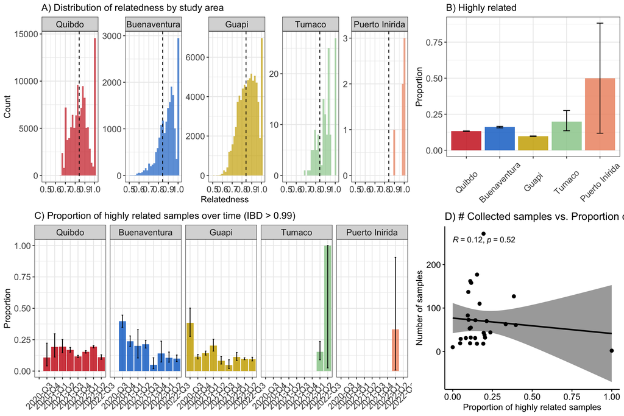

**Figure 8:** Effect of transmission on relatedness. A) Histogram of the distribution of pairwise genetic relatedness by study area (Panels). The dashed vertical line represents the average genetic relatedness in the overall population. B) Proportion of highly related samples (IBD > 0.99) in each study area. C) Proportion of highly related samples over year quarters in each study area. D) Spearman correlation of the proportion of highly related samples per year quarter in each estudy area and the number of collected samples by passive case detection.

# 4 Measuring geographic connectivity

Malaria transmission is heterogeneous throughout the Colombian territory, and it is mainly concentrated in transmission foci where demographic and environmental factors favor the interaction between the two hosts of the parasite, humans and Anopheles mosquitoes. Operationally, disease control units are defined based on sub-national administrative divisions. The connectivity or dispersal pattern of the parasite between these geographic units may limit progress in disease control if activities are not properly coordinated. This connectivity is mainly influenced by human movement, and can be inferred by estimating the proportion of genetically closely related parasites between the different areas.

The average genetic relatedness and the proportion of highly related samples were higher among Buenaventura, Guapi and Tumaco (mean $r$ = 0.867, proportion = 0.091) than between Quibdo and the other three study sites located in the Pacific coast (mean $r$ = 0.825, proportion = 0.017). No conectivity was oberved between Puerto Inirida and the other four study sites. The results suggest higher connectivity or mobilization of parasites between Buenaventura, Guapi and Tumaco, than Quibdo and these three study areas.

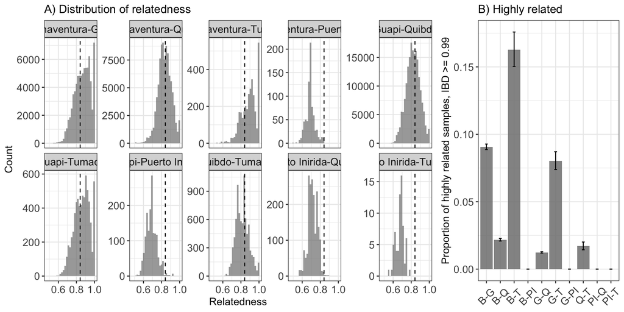